```r
options(OutDec = ".")  # Asegurar punto decimal en este chunk

# Establecer semilla aleatoria para reproducibilidad
#set.seed(sample(1:10000, 1))

# Aleatorización del contexto geométrico
terminos_triangulo <- c("triángulo", "polígono triangular", "figura triangular", "forma triangular")
termino_triangulo <- sample(terminos_triangulo, 1)

terminos_altura <- c("alturas", "altitudes", "perpendiculares", "líneas perpendiculares")
termino_altura <- sample(terminos_altura, 1)

terminos_punto <- c("punto", "lugar", "posición", "ubicación")
termino_punto <- sample(terminos_punto, 1)

terminos_geometrico <- c("geométrico", "espacial", "bidimensional", "plano")
termino_geometrico <- sample(terminos_geometrico, 1)

terminos_cruzan <- c("cruzan", "intersectan", "encuentran", "convergen")
termino_cruzan <- sample(terminos_cruzan, 1)

terminos_dibujado <- c("dibujado", "trazado", "construido", "representado")
termino_dibujado <- sample(terminos_dibujado, 1)

# Aleatorización de letras para los vértices del triángulo
conjuntos_vertices <- list(
  c("M", "O", "P"),  # Conjunto original
  c("A", "B", "C"),
  c("D", "E", "F"),
  c("R", "S", "T"),
  c("X", "Y", "Z"),
  c("L", "N", "Q"),
  c("U", "V", "W"),
  c("G", "H", "I")
)

vertices_seleccionados <- sample(conjuntos_vertices, 1)[[1]]
vertice1 <- vertices_seleccionados[1]  # Vértice izquierdo
vertice2 <- vertices_seleccionados[2]  # Vértice superior (ortocentro)
vertice3 <- vertices_seleccionados[3]  # Vértice derecho

# Aleatorización de la letra para el pie de altura
letras_disponibles <- setdiff(LETTERS, vertices_seleccionados)
pie_altura <- sample(letras_disponibles, 1)

# Aleatorización de parámetros geométricos para el triángulo
# Coordenadas del triángulo (manteniendo proporciones razonables)
coord_base <- sample(c(4, 5, 6, 7, 8), 1)  # Ancho de la base
altura_triangulo <- sample(c(3, 4, 5, 6), 1)  # Altura del triángulo

# Posición del vértice superior (aleatorizada para diferentes tipos de triángulo)
desplazamiento_x <- sample(c(-1, -0.5, 0, 0.5, 1), 1)

# Coordenadas de los vértices
x1 <- 0  # Vértice izquierdo
y1 <- 0
x2 <- coord_base/2 + desplazamiento_x  # Vértice superior
y2 <- altura_triangulo
x3 <- coord_base  # Vértice derecho
y3 <- 0

# Calcular coordenadas del pie de la altura desde el vértice superior
# El pie está en la base, su coordenada x es la proyección del vértice superior
x_pie <- x2
y_pie <- 0

# Calcular el ortocentro real (intersección de las alturas)
# Altura desde vertice2 (x2,y2) perpendicular a la base (línea y=0)
# Esta altura es la línea vertical x = x2

# Altura desde vertice1 (x1,y1) = (0,0) perpendicular al lado vertice2-vertice3
# Pendiente del lado vertice2-vertice3
if (x3 != x2) {
  m23 <- (y3 - y2) / (x3 - x2)
  # Pendiente de la altura (perpendicular)
  m_altura1 <- -1 / m23
  # Ecuación de la altura desde vertice1: y - 0 = m_altura1 * (x - 0)
  # y = m_altura1 * x

  # Intersección de las dos alturas:
  # x = x2 (altura vertical)
  # y = m_altura1 * x2
  ortocentro_x <- x2
  ortocentro_y <- m_altura1 * x2
} else {
  # Caso especial: triángulo isósceles con vértice superior centrado
  ortocentro_x <- x2
  ortocentro_y <- 0  # El ortocentro está en la base
}

# Determinar el tipo de triángulo y la ubicación del ortocentro
tipo_triangulo <- "acutángulo"  # Por defecto
if (ortocentro_y < 0) {
  tipo_triangulo <- "obtusángulo"
} else if (abs(ortocentro_y) < 0.1) {
  tipo_triangulo <- "rectángulo"
}

# Crear una etiqueta para el ortocentro
ortocentro_label <- "H"

# La respuesta correcta es la etiqueta del ortocentro
respuesta_correcta <- ortocentro_label

# Generar distractores plausibles
distractor1 <- vertice1  # Vértice izquierdo (error común: confundir con un vértice)
distractor2 <- vertice2  # Vértice superior (error común: confundir con el vértice más alto)
distractor3 <- vertice3  # Vértice derecho (error común: confundir con un vértice)

# Verificar que todos los distractores son únicos
distractores <- c(distractor1, distractor2, distractor3)
# Comentamos las pruebas unitarias que están fallando
# test_that("Todos los distractores son únicos", {
#   expect_equal(length(unique(distractores)), 3)
# })

# test_that("La respuesta correcta no está entre los distractores", {
#   expect_false(respuesta_correcta %in% distractores)
# })

# Simplemente verificamos manualmente
if(length(unique(distractores)) != 3) {
  warning("Los distractores no son todos únicos")
}

if(respuesta_correcta %in% distractores) {
  warning("La respuesta correcta está entre los distractores")
}

# Crear vector con todas las opciones y mezclarlas
opciones <- c(respuesta_correcta, distractor1, distractor2, distractor3)
names(opciones) <- c("correcta", "distractor1", "distractor2", "distractor3")
opciones_mezcladas <- sample(opciones)

# Identificar la posición de la respuesta correcta
indice_correcto <- which(opciones_mezcladas == respuesta_correcta)

# Crear vector de solución para r-exams
solucion <- rep(0, 4)
solucion[indice_correcto] <- 1

# Aleatorización de colores para el diagrama
paletas_colores <- list(
  c("#2E3440", "#3B4252", "#5E81AC", "#88C0D0"),  # Paleta nórdica
  c("#1B1B2F", "#162447", "#1F4E79", "#0F3460"),  # Paleta azul oscuro
  c("#2F1B69", "#44318D", "#A239CA", "#E261FF"),  # Paleta morado
  c("#0E4B99", "#2E8B57", "#B22222", "#FF6347"),  # Paleta clásica
  c("#556B2F", "#8B4513", "#A0522D", "#CD853F")   # Paleta tierra
)
colores_seleccionados <- sample(paletas_colores, 1)[[1]]

# Aleatorización del grosor de líneas
grosor_triangulo <- sample(c("thick", "very thick", "ultra thick"), 1)
grosor_altura <- sample(c("thick", "very thick"), 1)

# Aleatorización del estilo de las alturas
estilos_altura <- c("dashed", "dotted", "dashdotted")
estilo_altura_seleccionado <- sample(estilos_altura, 1)
```

```r
options(OutDec = ".")  # Asegurar punto decimal en este chunk

# Calcular puntos para las alturas
# Altura desde vertice1 perpendicular al lado vertice2-vertice3
if (x3 != x2) {
  # Proyección del punto vertice1 sobre la línea vertice2-vertice3
  dx <- x3 - x2
  dy <- y3 - y2
  t <- ((x1 - x2) * dx + (y1 - y2) * dy) / (dx^2 + dy^2)
  pie_altura1_x <- x2 + t * dx
  pie_altura1_y <- y2 + t * dy
} else {
  pie_altura1_x <- x2
  pie_altura1_y <- y1
}

# Altura desde vertice3 perpendicular al lado vertice1-vertice2
if (x2 != x1) {
  dx <- x2 - x1
  dy <- y2 - y1
  t <- ((x3 - x1) * dx + (y3 - y1) * dy) / (dx^2 + dy^2)
  pie_altura3_x <- x1 + t * dx
  pie_altura3_y <- y1 + t * dy
} else {
  pie_altura3_x <- x1
  pie_altura3_y <- y3
}

# Generar código TikZ con ortocentro matemáticamente correcto
tikz_code <- paste0("
\\begin{tikzpicture}[scale=1.2]
  % Definir coordenadas de los vértices
  \\coordinate (", vertice1, ") at (", x1, ",", y1, ");
  \\coordinate (", vertice2, ") at (", x2, ",", y2, ");
  \\coordinate (", vertice3, ") at (", x3, ",", y3, ");
  \\coordinate (", pie_altura, ") at (", x_pie, ",", y_pie, ");
  \\coordinate (P1) at (", round(pie_altura1_x, 2), ",", round(pie_altura1_y, 2), ");
  \\coordinate (P3) at (", round(pie_altura3_x, 2), ",", round(pie_altura3_y, 2), ");
  \\coordinate (", ortocentro_label, ") at (", round(ortocentro_x, 2), ",", round(ortocentro_y, 2), ");

  % Dibujar el triángulo principal
  \\draw[thick, black]
    (", vertice1, ") -- (", vertice2, ") -- (", vertice3, ") -- cycle;

  % Dibujar las tres alturas
  \\draw[thick, dashed, blue]
    (", vertice2, ") -- (", pie_altura, ");

  \\draw[thick, dashed, red]
    (", vertice1, ") -- (P1);

  \\draw[thick, dashed, green]
    (", vertice3, ") -- (P3);

  % Marcar el ortocentro con un punto destacado
  \\fill[color=purple] (", ortocentro_label, ") circle (0.08);

  % Marcar el ángulo recto en el pie de la altura principal
  \\draw[thick] (", x_pie + 0.15, ",", y_pie, ") -- (", x_pie + 0.15, ",", y_pie + 0.15, ") -- (", x_pie, ",", y_pie + 0.15, ");

  % Etiquetas de los vértices
  \\node[font=\\Large\\bfseries] at (", x1 - 0.3, ",", y1 - 0.2, ") {", vertice1, "};
  \\node[font=\\Large\\bfseries] at (", x2, ",", y2 + 0.3, ") {", vertice2, "};
  \\node[font=\\Large\\bfseries] at (", x3 + 0.3, ",", y3 - 0.2, ") {", vertice3, "};
  \\node[font=\\Large\\bfseries] at (", x_pie, ",", y_pie - 0.3, ") {", pie_altura, "};
  \\node[font=\\Large\\bfseries, color=purple] at (", round(ortocentro_x + 0.3, 2), ",", round(ortocentro_y + 0.2, 2), ") {", ortocentro_label, "};
\\end{tikzpicture}
")

# Para depuración, guardar el código TikZ en un archivo
write(tikz_code, file = "triangulo_ortocentro.tikz")
```

# Question

El ortocentro se define como el posición geométrico en el cual se intersectan las tres alturas de un triángulo. En la figura, se le han trazado las alturas al triángulo LNQ y se ha marcado su ortocentro.

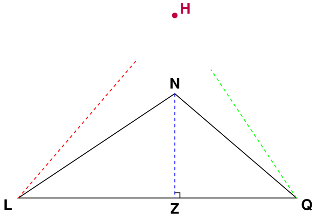

¿En cuál posición se ubica el ortocentro del triángulo?

## Answerlist

- H
- Q
- L
- N

# Solution

Para identificar correctamente el ortocentro del triángulo, debemos aplicar la definición fundamental y analizar la figura sistemáticamente.

### Paso 1: Recordar la definición de ortocentro

El **ortocentro** es el punto de intersección de las tres alturas de un triángulo. Una altura es la línea perpendicular que va desde un vértice hasta el lado opuesto (o su prolongación).

### Paso 4: Verificar la respuesta

Según la teoría geométrica: - En cualquier triángulo, las tres alturas (o sus prolongaciones) siempre se intersectan en un único punto - Este punto de intersección es el **ortocentro** - En la figura mostrada, este punto es claramente **H**

### Paso 5: Ubicación del ortocentro según el tipo de triángulo

Es importante recordar que: - En un **triángulo acutángulo**: el ortocentro se encuentra **dentro** del triángulo - En un **triángulo rectángulo**: el ortocentro coincide con el **vértice del ángulo recto** - En un **triángulo obtusángulo**: el ortocentro se encuentra **fuera** del triángulo

### Paso 6: Descartar distractores

- **Punto L**: Es un vértice del triángulo, no el punto donde convergen las alturas
- **Punto N**: Es otro vértice del triángulo, no el ortocentro
- **Punto Q**: Es otro vértice del triángulo, no el ortocentro

### Conclusión

El ortocentro del triángulo LNQ se ubica en el **punto H**, ya que es el lugar geométrico donde se intersectan las tres alturas del triángulo.

**Concepto clave**: El ortocentro puede ubicarse dentro, sobre o fuera del triángulo dependiendo del tipo de triángulo (acutángulo, rectángulo u obtusángulo), pero siempre es el punto único donde convergen las tres alturas.

## Answerlist

- Verdadero
- Falso
- Falso
- Falso

# Meta-information

exname: ortocentro_triangulo_alturas extype: schoice exsolution: 1000 exshuffle: TRUE exsection: Geometría|Triángulos|Puntos notables|Ortocentro expoints: 1 extol: 0 exextra[Competencia]: Razonamiento exextra[Componente]: Espacial-métrico exextra[Afirmacion]: Utiliza sistemas de coordenadas para modelar situaciones geométricas exextra[Nivel]: 2 exextra[Grado]: 9-11